# TP2_NAOUMI_KILANI

# Extra:

**As proposed by M.Chainais, let's see what happens if we use LDA with non linear combinations of features**

```python
from sklearn.preprocessing import PolynomialFeatures
```

```
time: 496 µs
```

```python
Nx1=120 # number of samples for display
Nx2=120
x1=np.linspace(-2.5,1.5,Nx1)  # sampling of the x1 axis
x2=np.linspace(-0.5,4,Nx2)  # sampling of the x2 axis
```

```
time: 1.99 ms
```

( we are aware that some variables used in he code below are global variables)

```python
def DRAW_LDA(polydegree,train,test): # a function that takes as an input the rank of the polynomial degree we want to see
                                     # training set and test set
                                     # Returns: a plot of the decisio boundary and the misclassification error
    poly_features = PolynomialFeatures(polydegree,include_bias=False)
    Dataset = np.vstack((train,test))
    x = poly_features.fit_transform(Dataset[:,1:])
    Dataset_ =np.hstack((Dataset,x[:,2:]))
    train,test = Dataset_[:99,:],Dataset_[100:,:]
    clf = LinearDiscriminantAnalysis()
    clf.fit(train[:,1:], train[:,0])
    GRID=[]
    for x in x1:
        for y in x2:
            dot=poly_features.fit_transform([[x,y]])
            cl= clf.predict(dot)
            GRID.append([cl,x,y])
    GRID=np.array(GRID)
    Error = 1 - count_nonzero(clf.predict(test[:,1:]) == test[:,0])/len(test)
    plt.figure(figsize=(15,7))
    plt.xlabel("X")
    plt.ylabel("Y")
    plt.scatter(GRID[GRID[:,0]==1][:,1],GRID[GRID[:,0]==1][:,2], color="r",label="LDA Class 1 domain",marker=".")
    plt.scatter(GRID[GRID[:,0]==2][:,1],GRID[GRID[:,0]==2][:,2], color="b",label="LDA Class 2 domain",marker=".")
    plt.scatter(train[train[:,0]==1][:,1],train[train[:,0]==1][:,2], color="r")
    plt.scatter(train[train[:,0]==2][:,1],train[train[:,0]==2][:,2], color="b")
    plt.title("Boundary LDA(degree polynomial " +str(polydegree)+") and training set || error on test = "+str(Error))
    plt.legend();
```

```
time: 4 ms
```

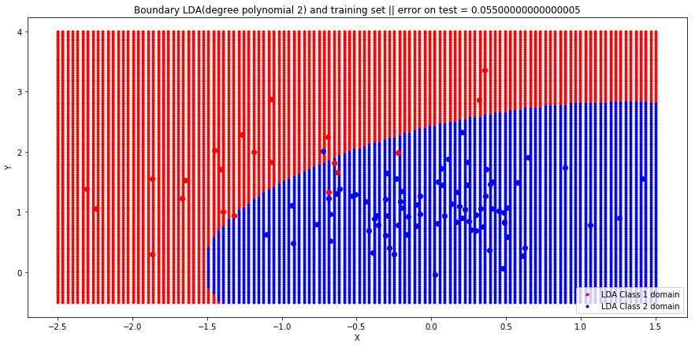

```
time: 2.13 s
```

```python
DRAW_LDA(2,train,test)
```

This first plot looks the same as the QDA boundary (as explained by M.Chainais)

Let's see now what happens if we push the polynomial combination of features to higher degrees)

[figure not shown]

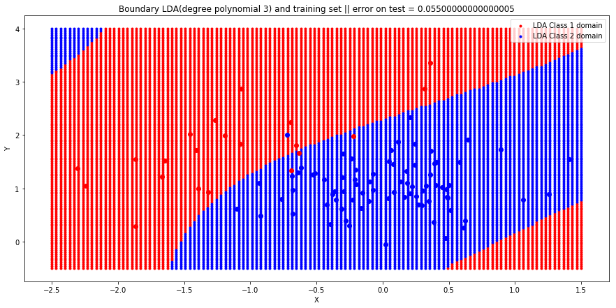

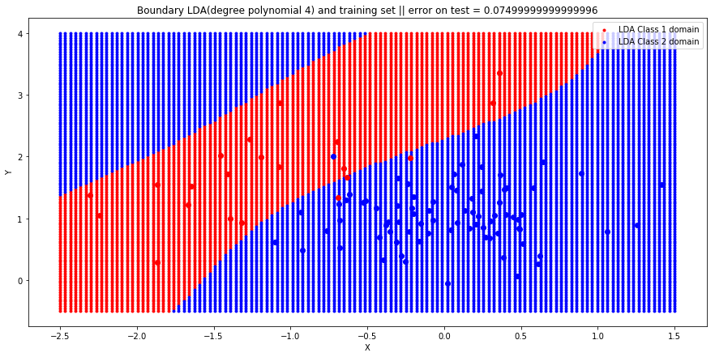

```
time: 5.03 s
```

```python
fig=plt.figure(figsize=(15,5))
ax1 = fig.add_subplot(121)
ax1= DRAW_LDA(3,train,test)
ax2 = fig.add_subplot(122)
ax2=DRAW_LDA(4,train,test)
```

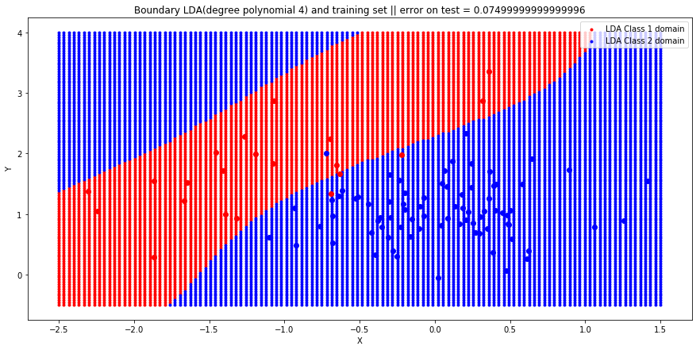

```
time: 2.7 s
```

```python
DRAW_LDA(4,train,test)
```

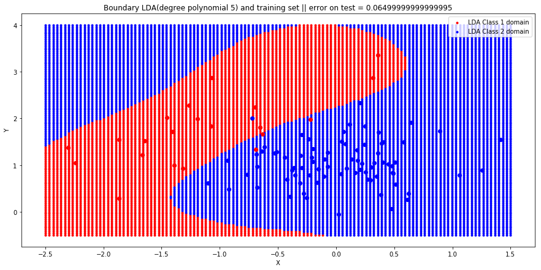

```
time: 3.25 s
```

```python
DRAW_LDA(5,train,test)
```

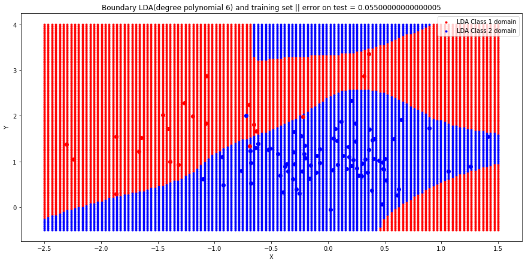

```
time: 3.7 s
```

```python
DRAW_LDA(6,train,test)
```

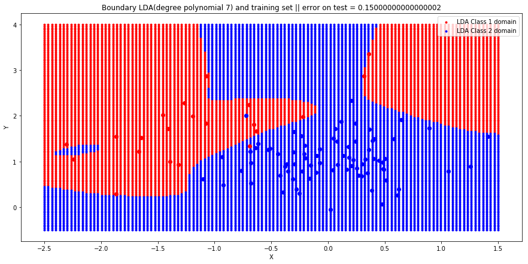

```
time: 4.34 s
```

```python
DRAW_LDA(7,train,test)
```

We can see that there is no need to ass more complexity ( in this simple example and it may be true dor other cases) as we do not gain that much precision by pushing the degree higher.